# HTML-ERIKA

Erika Pinto

25 de febrero de 2020

## opciones en los fragmentos de código

- *eval*: TRUE. si queremos evaluar el código e incluir los resultados

```r
summary(pressure)
```

- *echo*: TRUE. Indica si muestra el código a la par que los resultados. Incluyo el ejemplo eval = FALSE & echo = TRUE

Incluyo el ejmplo eval = TRUE & echo = FALSE

```
##   temperature     pressure
##  Min.   :  0   Min.   :  0.0002
##  1st Qu.: 90   1st Qu.:  0.1800
##  Median :180   Median :  8.8000
##  Mean   :180   Mean   :124.3367
##  3rd Qu.:270   3rd Qu.:126.5000
##  Max.   :360   Max.   :806.0000
```

- *collapse*: FALSE. debe combunar la salida del texto y el codigo fuente de la misma salida

```r
summary(pressure)
##   temperature     pressure
##  Min.   :  0   Min.   :  0.0002
##  1st Qu.: 90   1st Qu.:  0.1800
##  Median :180   Median :  8.8000
##  Mean   :180   Mean   :124.3367
##  3rd Qu.:270   3rd Qu.:126.5000
##  Max.   :360   Max.   :806.0000
```

- *warning*, *message* y *error*: TRUE. si se muestran
- *include*: si se debe inclur algo de un fragmento el codigo en el documento de salida.

```
##   temperature     pressure
##  Min.   :  0   Min.   :  0.0002
##  1st Qu.: 90   1st Qu.:  0.1800
##  Median :180   Median :  8.8000
##  Mean   :180   Mean   :124.3367
##  3rd Qu.:270   3rd Qu.:126.5000
##  Max.   :360   Max.   :806.0000
```

and we can also include code in the same line as the temperature 180

## Including Plots

- *fig.widht* y *fig.height*: especificamos el tamano en pulgadas. Tambien podemos especificarlo con *fig.dim* = c(6,4), que seria 6 ancho y 4 alto en pulgadas.
- *out.widht* y *out.height*: tamano escalado de salida
- *fig.align*: centrado de la figura
- *fig.cap*: pie de figura

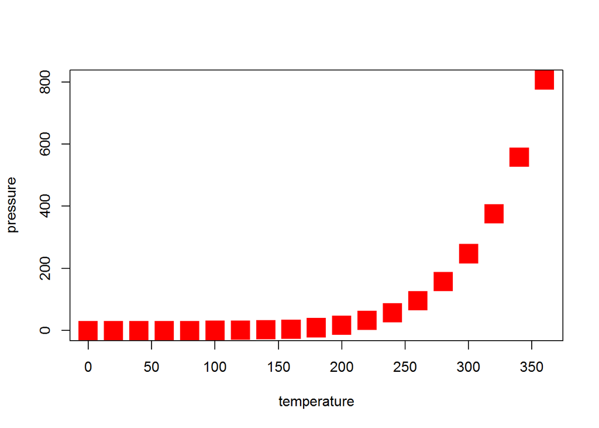

figura 1. Relacion entre la presion y la temperatura

```r
plot (pressure, cex = 3, pch = 15, col= "red")
```

## TABLAS con R Markdown

Vamos a hacer la peor tabla del mundo

| Esta es la peor tabla | columna |
| --- | --- |
| donde podemos incluir | celdas y columnas |
| cada vez que queramos | poco automaticamente |

we can also include code in the same line as the mean of the speed 15.4 #aparece directamente la media